*Created by Petteri Nevavuori <petteri.nevavuori@gmail.com>*

**CHIO & FREEMAN: MACHINE LEARNING & SECURITY (2018)**  
*Otsikot kirjan mukaan, muutoin suomeksi.*

# Adversarial Machine Learning

Koneoppimisen käyttöasteen noustessa sen luotettavuus on entistä tarkemman syynin alla, sillä vihamielinen vaikuttaminen ulottuu myös malleihin. Vihamielisen koneoppimisen (*adversarial machine learning*) tutkimus keskittyy mallinnustutkimukseen vihamielisissä ympäristöissä. Tällä alueella on onnistuttu toteuttamaan hyökkäyksiä mm. antivirusohjelmistoja ja roskapostisuotimia vastaan. Mallinnusmenetelmien haavoittuvuudet voivat johtua itse algoritmien rajoituksista, toteutuksesta tai näiden yhdistelmästä.

## Terminology

Tutkimuksen alkuvaiheissa keskityttiin mm. laadullista analyysiä helpottavan taksonomian muodostamiseen. Vihamielisen koneoppimisen kolme ulottuvuutta ovat tämän taksonomian mukaisesti:

- *Vaikutus*: Toimintaan vaikuttavat hyökkäykset (*causative attacks*) pyrkivät vaikuttamaan jo koulutuksessa käytettävään dataan. Heikoimmassa asemassa ovat näissä hyökkäyksissä jatkuvasti oppivat menetelmät (*online algorithms*), jotka pyrkivät oppimaan jatkuvasti uusista havainnoista ja tarkentamaan päätösrajapintojaan ajan myötä. Tutkivat hyökkäykset (*exploratory attacks*) keskittyvät vuorostaan vain koulutuksen jälkeisen mallin toiminnan ymmärtämiseen ja täten hyväksikäyttöön.
- *Tarkkuus*: Kohdistetut hyökkäykset (*targeted attacks*) pyrkivät vaikuttamaan ohjatusti ja aiotusti muuttamaan mallin päätösrajapintaa tietyn tavoitteen mukaiseksi. Kohdistamattomat hyökkäykset (*indiscriminate attacks*) pyrkivät vain tekemään mallista ylipäätään epätarkemman ja epäluotettavan.
- *Tietoturvan loukkaus*: Yhtenäisyyteen kohdistuvat hyökkäykset (*integrity attacks*) pyrkivät vaikuttamaan malliin siten, että ne vähentävät oikein luokiteltujen havaintojen osuutta (*true positive, recall*). Saatavuuten kohdistuvat hyökkäykset (*availability attacks*) vuorostaan keskittyvät rampauttamaan kohdejärjestelmän mallin tunnistuskykyä, sillä väärien tunnistustulosten (*false positive*) lisääntyessä manuaalinen työmäärä kasvaa ja mallin kokonaisluotettavuus laskee.

## The Importance of Adversarial ML

Luottamus koneoppimisjärjestelmiä kohtaan ei ole kasvanut samaa tahtia niiden käyttöönoton kanssa, sillä mallien ohittaminen koetaan liian helpoksi. Vihamielisen koneoppimistutkimuksen päätehtävä on kuroa luottamuksen ja käyttöönoton välistä kuilua umpeen avaamalla käytettyjen mallien heikkouksia ja täten tarjoten kehittämiskohteita mallien kehittäjille. Kohteina ovat etenkin mallien selitettävyyden ja sisäisen toiminnan ymmärryksen lisääminen.

## Security Vulnerabilities in Machine Learning Algorithms

Koneoppimismenetelmiin kohdistuvat hyökkäykset ovat verraten uusi hyökkäysrajapinta, jota hyödyntämällä voidaan saada uusia reittejä kohdejärjestelmään hyökkäämiseksi. Kyseessä ei ole vain järjstelmien haavoittuvuuksien hyväksikäyttö, vaan ennemmin tilastollisten mallien toiminnan takaisinmallinnus ja siitä saatavan tiedon hyväksikäyttö jatko-operaatioiden toteuttamiseksi.

Monesti mallinnuksen lähtökohdat ovat naiiveja ja osin keinotekoisiakin: piirteet oletetaan riippumattomiksi, datajoukon jakauma harmittomaksi sekä datantuottoprosessia kuvaavaksi. Kun nämä oletukset lakkaavat pitämästä paikkansa, lakkaavat myös näitä oletuksia hyödyntävät mallit toimimasta. Siksi rikkomalla nämä piirteet itse datassa saadaan myös mallit toimimaan epäluotettavasti.

Kaikki mallinnus on myös lähtökohtaisesti epätäydellisellä datalla tavoiteltavaa laajemman ilmiön approksimointia. Kaikesta ei ole mahdollista kerätä kaikkea tietoa, joten käytössä on aina epätäydellinen kuvaus mallinnettavasta ilmiöstä. Näin ajateltuna jo pelkkä datajoukko voi jättää mallille sokeita pisteitä alueille, jotka voivat todellisuudessa olla kriittisen tärkeitä. Toisaalta mallinnuksen ollessa tietyssä mielessä datantuottoprosessin funktion approksimointia, on ongelmana myös tietty todellisen datan hienojakoisuuden hävittäminen ja täten hyväksikäytettävien kolojen oppimatta jääminen. Tämä ongelma koskee kaikkia malleja ja ongelman ydin palaa aina epätäydelliseen koulutusdatajoukkoon.

### Attack Transferability

Tutkijat ovat huomanneet, että tarkoituksellisesti muodostetu mallia huijaavat näytteet toimivat myös muissa, alkuperäisestä mallista riippumattomissa ja perustavasti eroavissakin malleissa. Tätä nimitetään hyökkäysten siirrettävyydeksi (*attack transferability*). Datan näkökulmasta vihamieliset havainnot ovat melko samankaltaisia algoritmien välillä. Käyttämällä vain testidatajoukkoa ja pelkkiä muutoin tuntemattoman mallin tuloksia tutkijat kykenivät kouluttamaan paikallisesti korvaavan mallin (*local substitute model*), mitä tutkimalla muodostettiin vihamielisiä havaintoja. Menetelmä on käytännöllinen sekä onnistuu, vaikkei kohdejärjestelmän mallista ole muuta tietoa kuin data ja tulokset.

## Attack Technique: Model Poisoning

Mallien myrkytys- eli harhautushyökkäykset (*red herring*) ovat jatkuvasti oppivien mallien ongelma. Niissä vakaus ja stationäärisyys korvataan muuntautumiskyvyllä, jotta malli pysyisi merkityksellisenä ja suorituskykyisenä. Tässä on samalla niiden heikkous, sillä niille voidaan aktiivisesti pyrkiä syöttämään valheellista dataa pyrkimyksenä joko kohdennetusti tai kohdistamattomasti rampauttamaan mallin luokittelu- tai ennustekykyä. Tämänkaltaiset hyökkäykset ovat lähtökohtaisesti toimintaan vaikuttavia (*causative*).

Näissä hyökkäyksissä oletus on, että hyökkääjällä on pääsy osaan mallin näkemästä datajoukosta ja että suurempi osuus varmistaa suuremmat vaikutusmahdollisuudet. Tällöin mallille syötetään verrattain lyhyessä ajanjaksossa mittava määrä dataa, mikä taas on havaittavissa soveltuvin keinoin (rajat, jne.). Mikäli hyökkääjä päättääkin syöttää dataa pidemmän ajanjakson yli, on havaitseminen vaikeampaa - vrt. keitettävä sammakko kylmässä vedessä. Näin toteutettuna jakauman muunnos voidaan saada näyttää luonnolliselta datan jakauman kehitykseltä.

### Example: Binary Classifier Poisoning Attack

Käytännön esimerkki palvelee aina hyvin, siksi sellainen esitetään myös tässäkin kohdin. Aloitetaan luomalla keinotekoinen datajoukko.

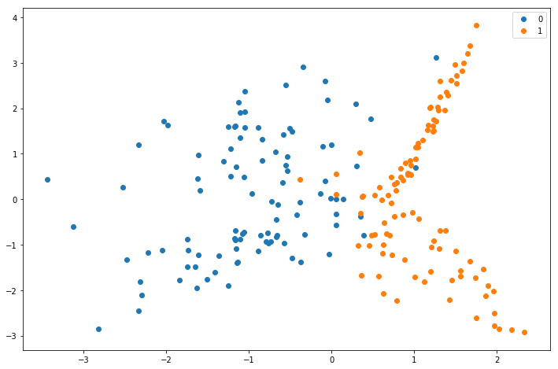

```python
from sklearn.datasets import make_classification
import matplotlib.pyplot as plt
%matplotlib inline

x, y = make_classification(n_samples=200, n_features=2, n_informative=2,n_redundant=0,weights=[.5,.5],random_state=0)

plt.rcParams['figure.figsize'] = 12,8
plt.scatter(x[y==0][:,0],x[y==0][:,1],label='0')
plt.scatter(x[y==1][:,0],x[y==1][:,1],label='1')
plt.legend()
plt.show()
```

Sovitetaan sen jälkeen datajoukkoon yksinkertainen neuroverkko.

```python
import numpy as np
from sklearn.neural_network import MLPClassifier

xx,yy = np.mgrid[-3:3:.1,-3:3:.1]
grid = np.c_[xx.ravel(), yy.ravel()]
model = MLPClassifier(max_iter=600,random_state=0).fit(x[:100],y[:100])
results = model.predict_proba(grid)[:,1].reshape(xx.shape)
```

Visualisoidaanpa seuraavaksi mallin päätösrajapinta. Seuraava funktio on kopioitu sellaisenaan [kirjan esimerkin notebookista](https://github.com/oreilly-mlsec/book-resources/blob/master/chapter8/classifier-poisoning.ipynb). Lisäämällä valedataa (*chaff*) voidaan alkuperäistä päätösrajapintaa muokata.

```python
def plot_decision_boundary(x, y, results, x_chaff=None, y_chaff=None, results_poisoned=None):
    xx,yy = np.mgrid[-3:3:.1,-3:3:.1]
    f, ax = plt.subplots(figsize=(9,6))
    ax.scatter(x[y==0][:,0], x[y==0][:,1], c='k', edgecolor="black", label='0')
    ax.scatter(x[y==1][:,0], x[y==1][:,1], c='w', edgecolor="black", label='1')
    if all([(x_chaff is not None),(y_chaff is not None),(results_poisoned is not None)]):
        ax.scatter(x_chaff[:,0], x_chaff[:, 1], c='w', marker="D", edgecolor="black", label='chaff')
        ax.contour(xx, yy, results, levels=[.5], cmap="gray", vmin=0, vmax=.8)
        ax.contour(xx, yy, results_poisoned, levels=[.5], cmap="gray")
    else:
        ax.contour(xx, yy, results, levels=[.5], cmap="gray")
    ax.set(aspect="equal", xlim=(-3, 3), ylim=(-3, 3))
    plt.legend()
    plt.show()
```

Visualisoidaan ensin alkuperäinen päätösrajapinta.

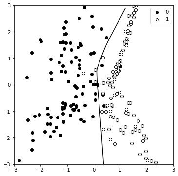

```python
plot_decision_boundary(x,y, results)
```

Visualisoidaanpa seuraavaksi valedatan lisäämisen vaikutusta.

```
Partial fit no. 5
```

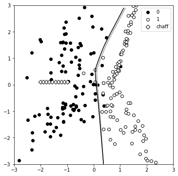

```
Partial fit no. 10
```

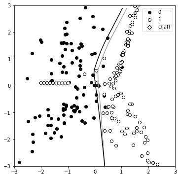

```python
num_chaff = 10
x_chaff = np.array([np.linspace(-2, -1, num_chaff), np.linspace(0.1, 0.1, num_chaff)]).T
y_chaff = np.ones(num_chaff)

for i in range(1,11):
    model.partial_fit(x_chaff,y_chaff)
    if i%5 == 0:
        print(f'Partial fit no. {i}')
        results_poisoned = model.predict_proba(grid)[:, 1].reshape(xx.shape)
        plot_decision_boundary(x, y, results, x_chaff, y_chaff, results_poisoned)
        print()
```

Otetaanpa vielä radikaali kuvaus yhteensä sadan uudelleenkoulutuksen vaikutuksesta.

```
Partial fit no. 100
```

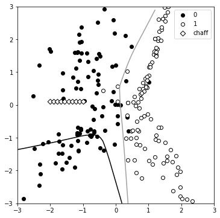

```python
for i in range(11,101):
    model.partial_fit(x_chaff,y_chaff)

print(f'Partial fit no. {i}')
results_poisoned = model.predict_proba(grid)[:, 1].reshape(xx.shape)
plot_decision_boundary(x, y, results, x_chaff, y_chaff, results_poisoned)
print()
```

Malli on täysin epäluotettava.

### Attacker knowledge

Kuten edellisestä esimerkistä voi huomata, jo pelkkä tieto mallin päätösrajapinnasta auttaa siinä, että mallille osaa syöttää halutun lopputuloksen tuottavia valehavaintoja. Miten hyökkääjä sitten saa selville tämän tiedon? Lähtökohtana on hyvä pitää, että hyökkääjällä on käytössään rajaton määrä mahdollisuuksia syöttää dataa sekä saada tietoa niiden luokittelutuloksista. Voisi ajatella, että hyökkääjän on mahdollista piirtää saamistaan tuloksista edellisen esimerkin tapainen kuva, ja määrittää siitä mahdollinen päätösrajapinta. Enää ei tarvita mitään muuta, kuin haluttuun suuntaan rajaa vieviä havaintoja ja niiden jatkuvaa syöttämistä mallille. Siksi mallien suojaus ja niiden luokittelutulosten salaus on elintärkeää.

### Defense Against Poisoning Attacks

Yksi tärkeä kysymys on reaaliaikaisten päivitysten todellinen tarpeellisuus - malli voi toimia reaaliaikaisesti, mutta tarvitseeko sen myös päivittyä siten? Jaksotetulla joukkokoulutuksella on mm. seuraavia etuja:

- Kerättyä dataa on mahdollista tarkastella mahdollisten outojen ryppäiden varalta (ks. edellisen kohdan valehavaintojen muoto)
- Pidempien ajanjaksojen tarkastelu auttaa myös huomaamaan hitaan keittämisen taktiikkaan perustuvat hyökkäykset paremmin
- Nopeat takaisinkytkentäloopit ovat hyökkääjien unelma välittömän vasteen ja siitä saatavan oman toiminnan vaikutusten arviointikyvyn kautta

Myrkytyshyökkäyksiä voidaankin havaita kootusta datajoukosta seuraavasti:

- Epänormaalien liikennevirtojen tunnistaminen esimerkiksi IP-osoitteesta tai jostain autonomisesta järjestelmästä
- Kootun joukon vertaaminen kalibrointidatajoukkoon
- Päätösrajapinnan läheisyyteen jäävien havaintojen määrien tarkastelu